# Example workflow

Below you can find a step-by-step guide how to visualize a graphic.

This is not obligatory, but maybe useful for anyone wanting to play around with data on their own time.

```r
#load data
library(gapminder)
library(tidyverse)
#subset the data
data_2007 <- gapminder |>
  filter(year == 2007)

#check the data
str(data_2007)
```

```
tibble [142 × 6] (S3: tbl_df/tbl/data.frame)
 $ country  : Factor w/ 142 levels "Afghanistan",..: 1 2 3 4 5 6 7 8 9 10 ...
 $ continent: Factor w/ 5 levels "Africa","Americas",..: 3 4 1 1 2 5 4 3 3 4 ...
 $ year     : int [1:142] 2007 2007 2007 2007 2007 2007 2007 2007 2007 2007 ...
 $ lifeExp  : num [1:142] 43.8 76.4 72.3 42.7 75.3 ...
 $ pop      : int [1:142] 31889923 3600523 33333216 12420476 40301927 20434176 8199783 708573 150448339 10392226 ...
 $ gdpPercap: num [1:142] 975 5937 6223 4797 12779 ...
```

First, lets explore the data with a histogram.

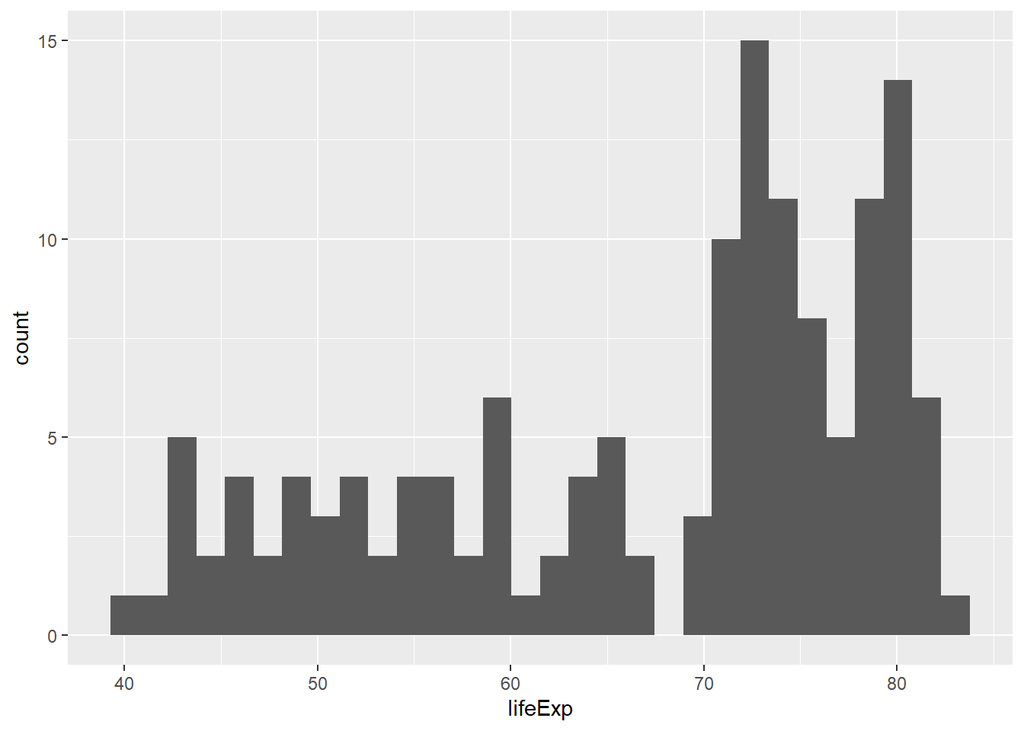

```r
ggplot(data_2007, aes(x = lifeExp)) +
  geom_histogram()
```

To make life easier, lets only focus on the top 10 and bottom 10 data points.

```r
data_2007_subset <- data_2007 |>
  filter( min_rank(desc(lifeExp)) <= 10 |
          min_rank(lifeExp) <= 10 ) |>
  arrange(lifeExp)

data_2007_subset
```

| country | continent | year | lifeExp | pop | gdpPercap |
| --- | --- | --- | --- | --- | --- |
| Swaziland | Africa | 2007 | 39.613 | 1133066 | 4513.4806 |
| Mozambique | Africa | 2007 | 42.082 | 19951656 | 823.6856 |
| Zambia | Africa | 2007 | 42.384 | 11746035 | 1271.2116 |
| Sierra Leone | Africa | 2007 | 42.568 | 6144562 | 862.5408 |
| Lesotho | Africa | 2007 | 42.592 | 2012649 | 1569.3314 |
| Angola | Africa | 2007 | 42.731 | 12420476 | 4797.2313 |
| Zimbabwe | Africa | 2007 | 43.487 | 12311143 | 469.7093 |
| Afghanistan | Asia | 2007 | 43.828 | 31889923 | 974.5803 |
| Central African Republic | Africa | 2007 | 44.741 | 4369038 | 706.0165 |
| Liberia | Africa | 2007 | 45.678 | 3193942 | 414.5073 |

[output cut: 10 more lines]

Lets plot this.

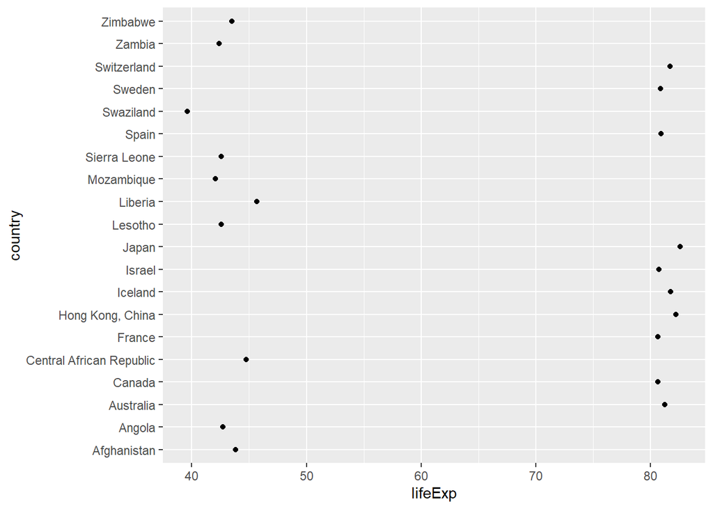

```r
ggplot(data_2007_subset, aes(x = lifeExp, y = country)) +
  geom_point()
```

The order is not very intuitive since ggplot uses alphabeetical order. Lets change this and add some colors and add a line to show, that we work with an age range.

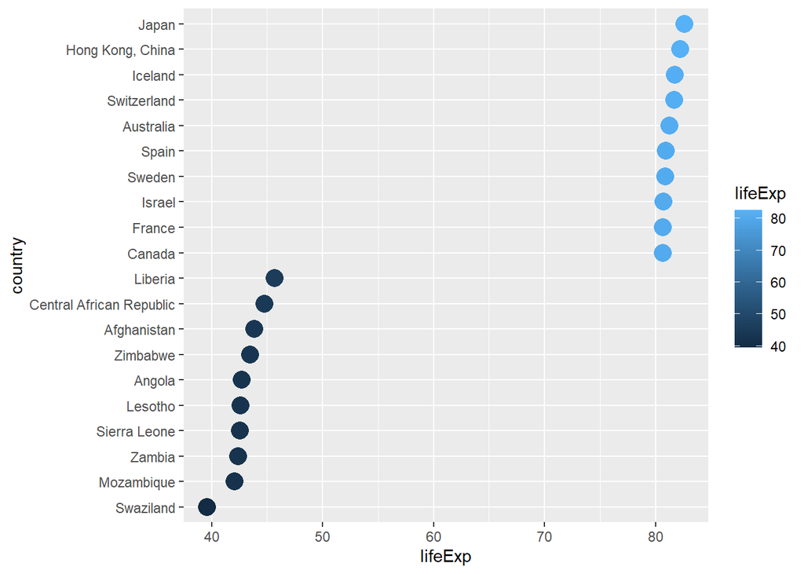

```r
#reorder levels
data_2007_subset$country <- factor(data_2007_subset$country,levels = as.character(data_2007_subset$country))

#plot
ggplot(data_2007_subset, aes(x = lifeExp, y = country, color = lifeExp)) +
  geom_point(size =5)
```

Now, lets add a line, to show that we work with a range of dates. geom_segment() adds line segments and requires two additional aesthetics: xend and yend.

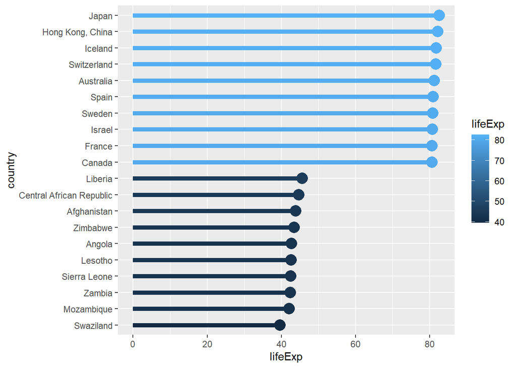

```r
#plot
ggplot(data_2007_subset, aes(x = lifeExp, y = country, color = lifeExp)) +
  geom_point(size =5) +
  geom_segment(aes(xend = 0, yend = country), size = 2)
```

We can also add the actual values.

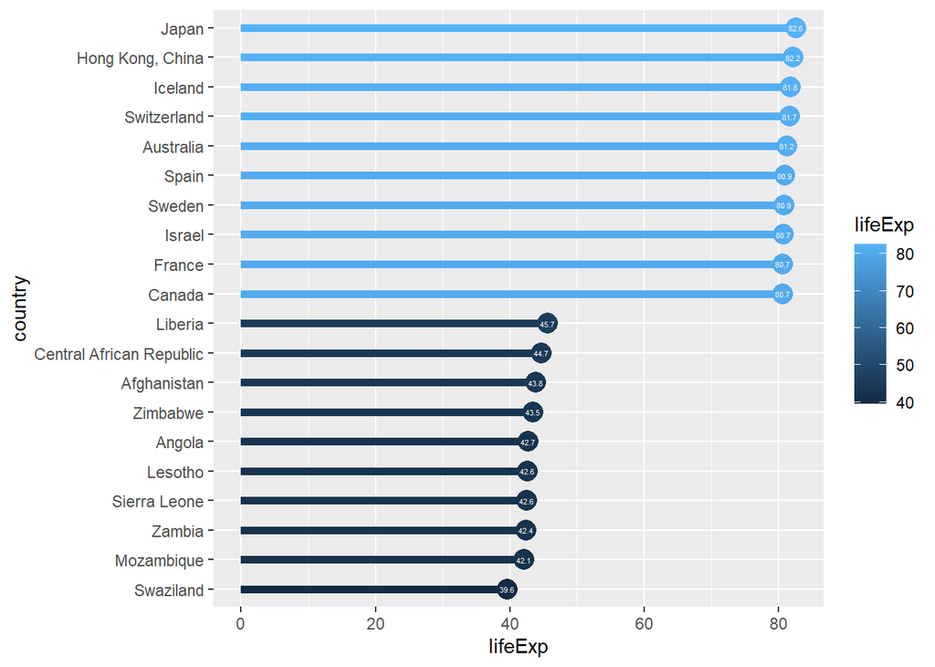

```r
#plot
ggplot(data_2007_subset, aes(x = lifeExp, y = country, color = lifeExp)) +
  geom_point(size =5) +
  geom_segment(aes(xend = 0, yend = country), size = 2) +
  geom_text(aes(label = round(lifeExp, digits = 1)), size =1.5, color = "white")
```

Now, lets clean up the scales.

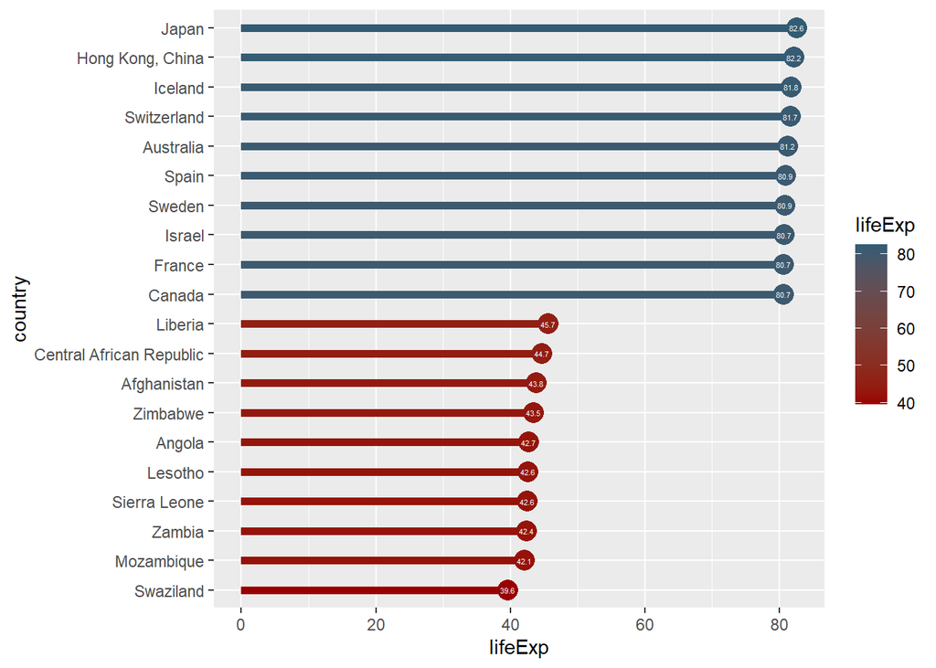

```r
#plot
ggplot(data_2007_subset, aes(x = lifeExp, y = country, color = lifeExp)) +
  geom_point(size =5) +
  geom_segment(aes(xend = 0, yend = country), size = 2) +
  geom_text(aes(label = round(lifeExp, digits = 1)), size =1.5, color = "white") +
  scale_colour_gradient(low = "#990000", high = "#325C74")
```

Add the x-axis to the top of the plot and remove the tick marks from the y-axis

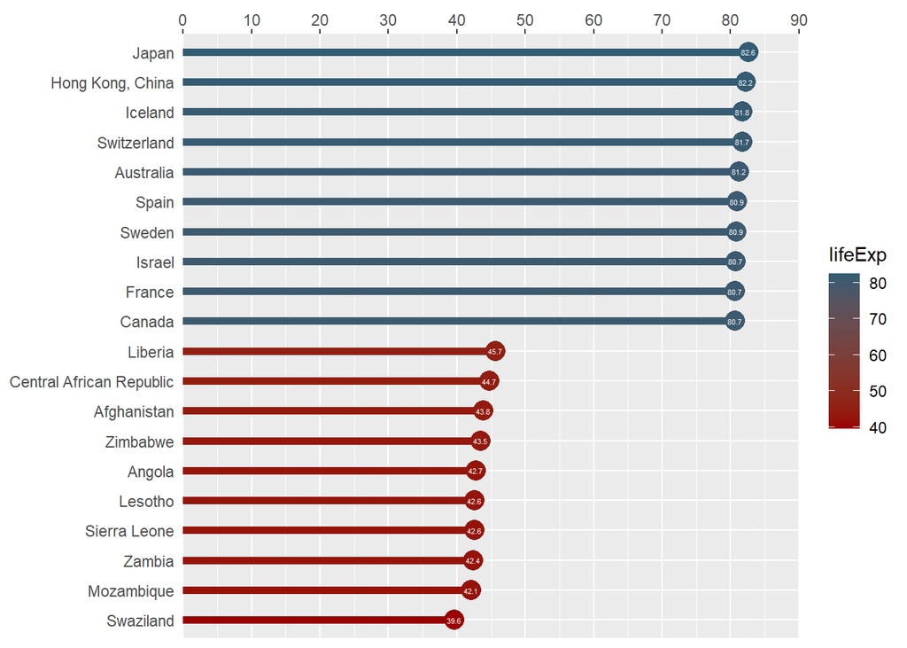

```r
#plot
ggplot(data_2007_subset, aes(x = lifeExp, y = country, color = lifeExp)) +
  geom_point(size =5) +
  geom_segment(aes(xend = 0, yend = country), size = 2) +
  geom_text(aes(label = round(lifeExp, digits = 1)), size =1.5, color = "white") +
  scale_colour_gradient(low = "#990000", high = "#325C74") +
  scale_x_continuous(position = "top", expand = c(0,0), limits = c(0,90), breaks = seq(0,90,10)) +
  theme(axis.title.x = element_blank(),
        axis.title.y = element_blank(),
        axis.ticks.y = element_blank())
```

Add a title and a caption to refer to the dataset.

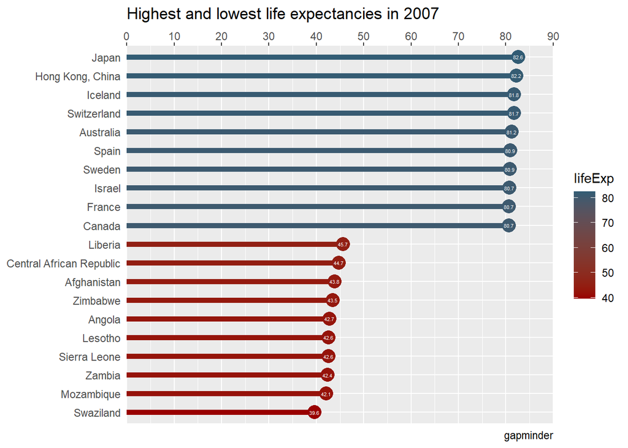

```r
#plot
ggplot(data_2007_subset, aes(x = lifeExp, y = country, color = lifeExp)) +
  geom_point(size =5) +
  geom_segment(aes(xend = 0, yend = country), size = 2) +
  geom_text(aes(label = round(lifeExp, digits = 1)), size =1.5, color = "white") +
  scale_colour_gradient(low = "#990000", high = "#325C74") +
  scale_x_continuous(position = "top", expand = c(0,0), limits = c(0,90), breaks = seq(0,90,10)) +
  theme(axis.title.x = element_blank(),
        axis.title.y = element_blank(),
        axis.ticks.y = element_blank()) +
  labs(title = "Highest and lowest life expectancies in 2007", caption = "gapminder")
```

Remove non-data ink

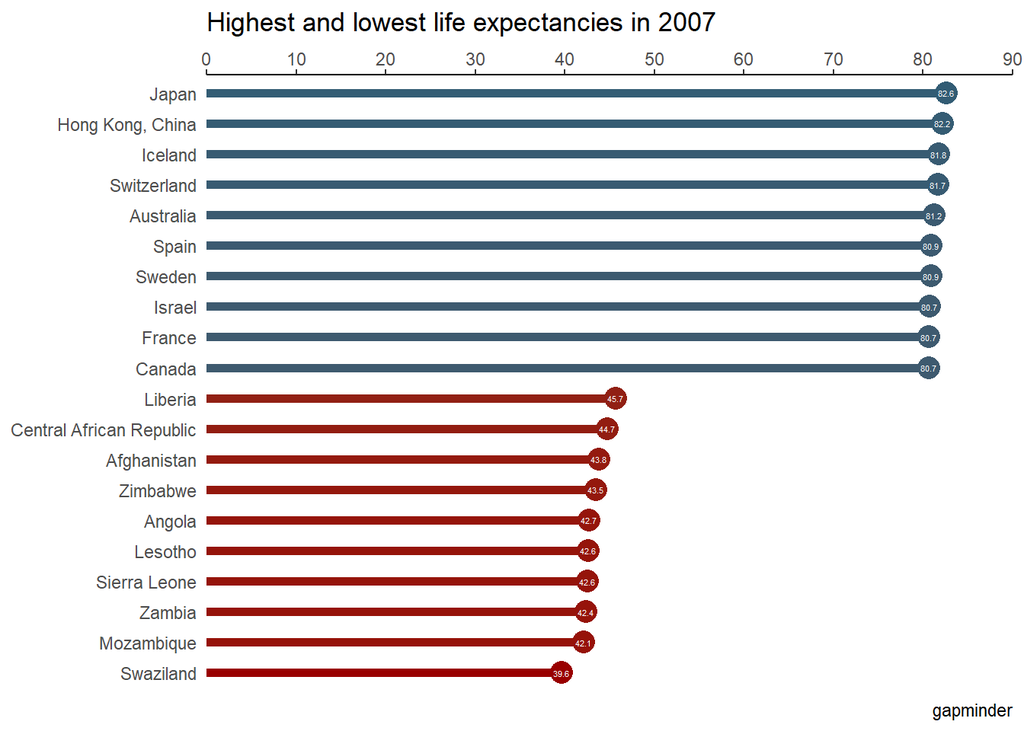

```r
#plot
ggplot(data_2007_subset, aes(x = lifeExp, y = country, color = lifeExp)) +
  geom_point(size =5) +
  geom_segment(aes(xend = 0, yend = country), size = 2) +
  geom_text(aes(label = round(lifeExp, digits = 1)), size =1.5, color = "white") +
  scale_colour_gradient(low = "#990000", high = "#325C74") +
  scale_x_continuous(position = "top", expand = c(0,0), limits = c(0,90), breaks = seq(0,90,10)) +
  theme(axis.title.x = element_blank(),
        axis.title.y = element_blank(),
        axis.ticks.y = element_blank()) +
  labs(title = "Highest and lowest life expectancies in 2007", caption = "gapminder") +
  theme(panel.grid = element_blank(),
        rect = element_blank(),
        axis.line.x.top = element_line(color = "black"),
        legend.position = "none")
```

```r
global_mean = mean(data_2007_subset$lifeExp)
global_mean
```

```
[1] 62.1544
```

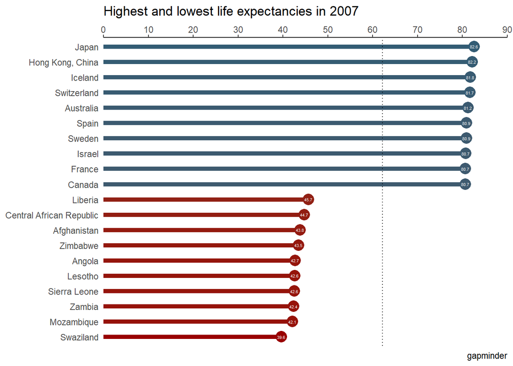

```r
#plot
ggplot(data_2007_subset, aes(x = lifeExp, y = country, color = lifeExp)) +
  geom_point(size =5) +
  geom_segment(aes(xend = 0, yend = country), size = 2) +
  geom_text(aes(label = round(lifeExp, digits = 1)), size =1.5, color = "white") +
  scale_colour_gradient(low = "#990000", high = "#325C74") +
  scale_x_continuous(position = "top", expand = c(0,0), limits = c(0,90), breaks = seq(0,90,10)) +
  theme(axis.title.x = element_blank(),
        axis.title.y = element_blank(),
        axis.ticks.y = element_blank()) +
  labs(title = "Highest and lowest life expectancies in 2007", caption = "gapminder") +
  theme(panel.grid = element_blank(),
        rect = element_blank(),
        axis.line.x.top = element_line(color = "black"),
        legend.position = "none") +
  geom_vline(xintercept = global_mean, linetype = "dotted")
```

Ideally, we add a label to our line as well. here, we use annotate() to add text and later a curve to the plot.

[figure not shown]

```r
#plot
ggplot(data_2007_subset, aes(x = lifeExp, y = country, color = lifeExp)) +
  geom_point(size =5) +
  geom_segment(aes(xend = 0, yend = country), size = 2) +
  geom_text(aes(label = round(lifeExp, digits = 1)), size =1.5, color = "white") +
  scale_colour_gradient(low = "#990000", high = "#325C74") +
  scale_x_continuous(position = "top", expand = c(0,0), limits = c(0,90), breaks = seq(0,90,10)) +
  theme(axis.title.x = element_blank(),
        axis.title.y = element_blank(),
        axis.ticks.y = element_blank()) +
  labs(title = "Highest and lowest life expectancies in 2007", caption = "gapminder") +
  theme(panel.grid = element_blank(),
        rect = element_blank(),
        axis.line.x.top = element_line(color = "black"),
        legend.position = "none") +
  geom_vline(xintercept = global_mean, linetype = "dotted") +
  annotate("text",
          label = "global mean \n average",
          x = global_mean + 5,
          y = 2,
          hjust = 0,
          size = 3,
          fontface = 3)
```

We can even add an arrow to make sure it is clear what the label refers to.

[figure not shown]

```r
#plot
ggplot(data_2007_subset, aes(x = lifeExp, y = country, color = lifeExp)) +
  geom_point(size =5) +
  geom_segment(aes(xend = 0, yend = country), size = 2) +
  geom_text(aes(label = round(lifeExp, digits = 1)), size =1.5, color = "white") +
  scale_colour_gradient(low = "#990000", high = "#325C74") +
  scale_x_continuous(position = "top", expand = c(0,0), limits = c(0,90), breaks = seq(0,90,10)) +
  theme(axis.title.x = element_blank(),
        axis.title.y = element_blank(),
        axis.ticks.y = element_blank()) +
  labs(title = "Highest and lowest life expectancies in 2007", caption = "gapminder") +
  theme(panel.grid = element_blank(),
        rect = element_blank(),
        axis.line.x.top = element_line(color = "black"),
        legend.position = "none") +
  geom_vline(xintercept = global_mean, linetype = "dotted") +
  annotate("text",
          label = "global mean \n average",
          x = global_mean + 5,
          y = 2,
          hjust = 0,
          size = 3,
          fontface = 3) +
  annotate( geom = "curve", x = global_mean + 6, y = 3, xend = global_mean, yend = 5,
            curvature = .3,
            arrow = arrow(length = unit(2, "mm"))
  )
```